# Pseudotime-Aware MI Network Analysis with miEdgeR

## Prepare a single “lineage” label for miEdgeR

`compute_pseudotime_mi_network()` expects a `cluster_field` + `cluster_id` to select cells. Because this vignette object is already subset to the epithelial lineage, we create a single label (lineage_demo) so the function can select all cells consistently.

```r
seurat_obj$lineage_demo <- "epithelial_lineage_demo"
```

## Compute pseudotime-resolved MI networks

For each pseudotime bin (n_bins = 3), we:

-select lineage cells, -filter genes by expression prevalence, -keep the top variable genes, -compute MI, -threshold to build a graph per bin.

```r
pt_results <- miEdgeR::compute_pseudotime_mi_network(
  seurat_obj     = seurat_obj,
  cluster_id     = "epithelial_lineage_demo",
  cluster_field  = "lineage_demo",
  pseudotime_col = "pseudotime1",
  assay_name     = "RNA",
  counts_layer   = "counts",
  data_layer     = "data",
  min_expr_pct   = 0.05,
  top_n_genes    = 2000,   # reduce for vignette runtime
  min_cells_bin  = 50,
  n_bins         = 3,
  n_cores        = max(1, parallel::detectCores() - 3)
)

cat("Valid bins:", sum(!sapply(pt_results, is.null)), "\n")
```

```
## Valid bins: 3
```

```r
names(pt_results)
```

```
## [1] "PT1" "PT2" "PT3"
```

## Summarize Bin Graphs

Quick summary of node and edge counts and density per bin to assess network complexity over pseudotime.

```r
for (bin in names(pt_results)) {
  if (!is.null(pt_results[[bin]])) {
    cat("Bin", bin, "- Vertices:", igraph::vcount(pt_results[[bin]]), "\n")
    cat("Bin", bin, "- Edges:", igraph::ecount(pt_results[[bin]]), "\n")
    cat("Bin", bin, "- Density:", igraph::graph.density(pt_results[[bin]]), "\n\n")
  } else {
    cat("Bin", bin, "- Skipped (insufficient cells)\n\n")
  }
}
```

```
## Bin PT1 - Vertices: 2000
## Bin PT1 - Edges: 100066
```

```
## Bin PT1 - Density: 0.05005803
##
## Bin PT2 - Vertices: 2000
## Bin PT2 - Edges: 100029
## Bin PT2 - Density: 0.05003952
##
## Bin PT3 - Vertices: 2000
## Bin PT3 - Edges: 100038
## Bin PT3 - Density: 0.05004402
```

## Community detection across pseudotime bins

We detect robust communities per bin using percolation (consensus filtering) followed by Leiden clustering and overlap expansion.

```r
comm_results <- detect_communities_across_bins(
  pt_results,
  min_size = 50,
  n_iterations = 100,
  edge_fraction = 0.6,
  freq_threshold = 0.5,
  percentile = 0.95,
  resolution_parameter = 0.5,
  overlap_threshold = 0.1
)
```

## Community sizes across bins

Bar plot showing how module sizes vary across pseudotime bins.

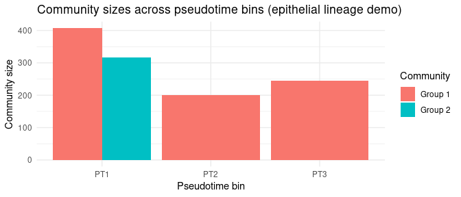

```r
comm_sizes_df <- bind_rows(lapply(comm_results, function(res) {
  data.frame(
    Bin = res$bin,
    Community = paste("Group", seq_along(res$sizes)),
    Size = res$sizes
  )
}))

p_comm_sizes <- ggplot(comm_sizes_df, aes(x = Bin, y = Size, fill = Community)) +
  geom_bar(stat = "identity", position = "dodge") +
  labs(
    title = "Community sizes across pseudotime bins (epithelial lineage demo)",
    x = "Pseudotime bin",
    y = "Community size"
  ) +
  theme_minimal()

print(p_comm_sizes)
```

## Edge Gain/Loss Analysis

Compare stable, gained, and lost edges between consecutive pseudotime bins.

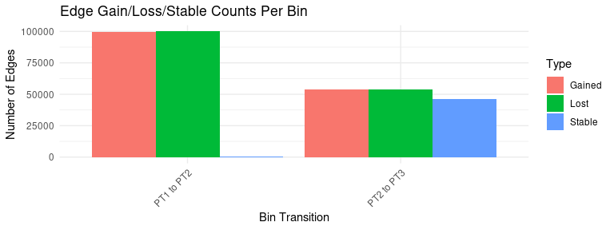

```r
result <- plot_edge_gain_loss(pt_results, cluster_id = "epithelial_lineage_demo")
print(result$plot)
```

```r
export_edge_changes <- function(edge_details, transition, write_csv = FALSE) {
  ed <- edge_details[[transition]]
  if (is.null(ed)) {
    message(transition, ": no edge data available")
    return(invisible(NULL))
  }

  out <- list()

  for (type in c("gained", "lost", "stable")) {
    edges <- ed[[type]]

    if (!is.data.frame(edges) || nrow(edges) == 0) {
      message(sprintf("%s – %s edges: none", transition, type))
      next
    }

    message(sprintf("%s – %s edges (showing first 10):", transition, type))
    print(utils::head(edges, 10))

    if (isTRUE(write_csv)) {
      utils::write.csv(
        edges,
        file = sprintf("%s_edges_%s.csv", type, gsub(" ", "_", transition)),
        row.names = FALSE
      )
    }

    out[[type]] <- edges
  }

  invisible(out)
}

# Inspect transitions
export_edge_changes(result$edge_details, "PT1 to PT2", write_csv = FALSE)
```

```
##               from              to    weight                              key
## 1  ENSG00000132475 ENSG00000163041 0.8393076 ENSG00000132475||ENSG00000163041
## 2  ENSG00000132475 ENSG00000175061 0.8775790 ENSG00000132475||ENSG00000175061
## 3  ENSG00000132475 ENSG00000233276 0.7885454 ENSG00000132475||ENSG00000233276
## 4  ENSG00000132475 ENSG00000170345 0.8530209 ENSG00000132475||ENSG00000170345
## 5  ENSG00000132475 ENSG00000171346 0.7581607 ENSG00000132475||ENSG00000171346
## 6  ENSG00000132475 ENSG00000173436 0.8115942 ENSG00000132475||ENSG00000173436
## 7  ENSG00000132475 ENSG00000189060 0.7905231 ENSG00000132475||ENSG00000189060
## 8  ENSG00000132475 ENSG00000206075 0.9418493 ENSG00000132475||ENSG00000206075
## 9  ENSG00000132475 ENSG00000233016 0.8018243 ENSG00000132475||ENSG00000233016
## 10 ENSG00000132475 ENSG00000102265 0.8888502 ENSG00000102265||ENSG00000132475
```

```
##               from              to    weight                              key
## 1  ENSG00000165949 ENSG00000205420 0.8101644 ENSG00000165949||ENSG00000205420
## 2  ENSG00000165949 ENSG00000187608 0.7407742 ENSG00000165949||ENSG00000187608
## 3  ENSG00000165949 ENSG00000089127 0.8008684 ENSG00000089127||ENSG00000165949
## 4  ENSG00000165949 ENSG00000157601 0.6492014 ENSG00000157601||ENSG00000165949
## 5  ENSG00000165949 ENSG00000196754 0.4695403 ENSG00000165949||ENSG00000196754
## 6  ENSG00000165949 ENSG00000185745 0.6102836 ENSG00000165949||ENSG00000185745
## 7  ENSG00000165949 ENSG00000126709 0.7516791 ENSG00000126709||ENSG00000165949
## 8  ENSG00000165949 ENSG00000176153 0.5700765 ENSG00000165949||ENSG00000176153
## 9  ENSG00000165949 ENSG00000090382 0.3328862 ENSG00000090382||ENSG00000165949
## 10 ENSG00000165949 ENSG00000130513 0.3398640 ENSG00000130513||ENSG00000165949
```

```
##                                 key       from_bin1         to_bin1 weight_bin1
## 1  ENSG00000062716||ENSG00000069275 ENSG00000062716 ENSG00000069275   0.3423191
## 2  ENSG00000062716||ENSG00000110651 ENSG00000110651 ENSG00000062716   0.3453957
## 3  ENSG00000062716||ENSG00000255302 ENSG00000062716 ENSG00000255302   0.3273968
## 4  ENSG00000069275||ENSG00000069849 ENSG00000069849 ENSG00000069275   0.3431681
## 5  ENSG00000069275||ENSG00000074695 ENSG00000074695 ENSG00000069275   0.3245518
## 6  ENSG00000069275||ENSG00000075142 ENSG00000075142 ENSG00000069275   0.3408251
## 7  ENSG00000069275||ENSG00000088205 ENSG00000088205 ENSG00000069275   0.3308917
## 8  ENSG00000069275||ENSG00000090263 ENSG00000090263 ENSG00000069275   0.3252155
## 9  ENSG00000069275||ENSG00000099783 ENSG00000099783 ENSG00000069275   0.4327832
## 10 ENSG00000069275||ENSG00000099901 ENSG00000099901 ENSG00000069275   0.4545048
##          from_bin2         to_bin2 weight_bin2
## 1  ENSG00000062716 ENSG00000069275   0.8041699
## 2  ENSG00000062716 ENSG00000110651   0.8053169
## 3  ENSG00000062716 ENSG00000255302   0.7758417
## 4  ENSG00000069849 ENSG00000069275   0.7663295
## 5  ENSG00000074695 ENSG00000069275   0.7706998
## 6  ENSG00000075142 ENSG00000069275   0.9267086
## 7  ENSG00000088205 ENSG00000069275   0.7567970
## 8  ENSG00000090263 ENSG00000069275   0.7528815
## 9  ENSG00000099783 ENSG00000069275   0.9077880
## 10 ENSG00000099901 ENSG00000069275   0.7752716
```

```r
export_edge_changes(result$edge_details, "PT2 to PT3", write_csv = FALSE)
```

```
##               from              to    weight                              key
## 2  ENSG00000132475 ENSG00000167757 0.6617774 ENSG00000132475||ENSG00000167757
## 3  ENSG00000132475 ENSG00000160180 0.6688909 ENSG00000132475||ENSG00000160180
## 4  ENSG00000132475 ENSG00000230937 0.6808156 ENSG00000132475||ENSG00000230937
## 5  ENSG00000132475 ENSG00000110092 0.6468686 ENSG00000110092||ENSG00000132475
## 6  ENSG00000132475 ENSG00000123416 0.6894104 ENSG00000123416||ENSG00000132475
## 7  ENSG00000132475 ENSG00000196141 0.7105651 ENSG00000132475||ENSG00000196141
## 8  ENSG00000132475 ENSG00000245694 0.7232935 ENSG00000132475||ENSG00000245694
## 9  ENSG00000132475 ENSG00000128016 0.6692642 ENSG00000128016||ENSG00000132475
## 10 ENSG00000132475 ENSG00000165264 0.6611582 ENSG00000132475||ENSG00000165264
## 11 ENSG00000132475 ENSG00000168938 0.8036315 ENSG00000132475||ENSG00000168938
```

```
##               from              to    weight                              key
## 1  ENSG00000132475 ENSG00000163041 0.8393076 ENSG00000132475||ENSG00000163041
## 3  ENSG00000132475 ENSG00000233276 0.7885454 ENSG00000132475||ENSG00000233276
## 4  ENSG00000132475 ENSG00000170345 0.8530209 ENSG00000132475||ENSG00000170345
## 5  ENSG00000132475 ENSG00000171346 0.7581607 ENSG00000132475||ENSG00000171346
## 6  ENSG00000132475 ENSG00000173436 0.8115942 ENSG00000132475||ENSG00000173436
## 7  ENSG00000132475 ENSG00000189060 0.7905231 ENSG00000132475||ENSG00000189060
## 8  ENSG00000132475 ENSG00000206075 0.9418493 ENSG00000132475||ENSG00000206075
## 9  ENSG00000132475 ENSG00000233016 0.8018243 ENSG00000132475||ENSG00000233016
## 10 ENSG00000132475 ENSG00000102265 0.8888502 ENSG00000102265||ENSG00000132475
## 11 ENSG00000132475 ENSG00000116717 0.9360866 ENSG00000116717||ENSG00000132475
```

```
##                                 key       from_bin1         to_bin1 weight_bin1
## 1  ENSG00000004779||ENSG00000008018 ENSG00000004779 ENSG00000008018   1.0031851
## 2  ENSG00000004779||ENSG00000008282 ENSG00000008282 ENSG00000004779   0.7718688
## 3  ENSG00000004779||ENSG00000008952 ENSG00000008952 ENSG00000004779   0.8426779
## 4  ENSG00000004779||ENSG00000009307 ENSG00000004779 ENSG00000009307   0.7832043
## 5  ENSG00000004779||ENSG00000014641 ENSG00000014641 ENSG00000004779   0.8042027
## 6  ENSG00000004779||ENSG00000023191 ENSG00000004779 ENSG00000023191   0.7640594
## 7  ENSG00000004779||ENSG00000034713 ENSG00000034713 ENSG00000004779   0.7621041
## 8  ENSG00000004779||ENSG00000041357 ENSG00000041357 ENSG00000004779   0.7976959
## 9  ENSG00000004779||ENSG00000042753 ENSG00000004779 ENSG00000042753   0.9371759
## 10 ENSG00000004779||ENSG00000044115 ENSG00000004779 ENSG00000044115   0.7777969
##          from_bin2         to_bin2 weight_bin2
## 1  ENSG00000004779 ENSG00000008018   0.9261386
## 2  ENSG00000008282 ENSG00000004779   0.6685313
## 3  ENSG00000008952 ENSG00000004779   0.6930169
## 4  ENSG00000009307 ENSG00000004779   0.7231743
## 5  ENSG00000014641 ENSG00000004779   0.7343461
## 6  ENSG00000023191 ENSG00000004779   0.6910035
## 7  ENSG00000034713 ENSG00000004779   0.8382371
## 8  ENSG00000041357 ENSG00000004779   0.6996282
## 9  ENSG00000004779 ENSG00000042753   0.8943679
## 10 ENSG00000044115 ENSG00000004779   0.7185351
```

## Gene-Pseudotime Correlation Density

Plot distribution of gene expression–pseudotime correlations to gauge overall trends.

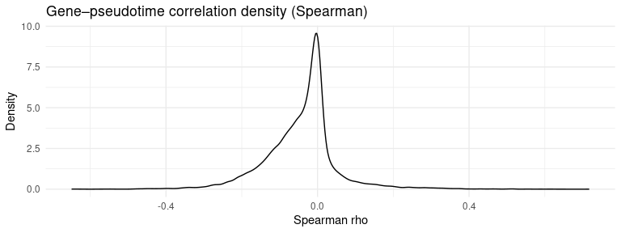

```r
gc_df <- gene_pt_correlation(
  seurat_obj,
  pseudotime_col = "pseudotime1",
  assay = "RNA",
  layer = "data",
  method = "spearman"
)

p_gc <- ggplot(gc_df, aes(x = Cor)) +
  geom_density(alpha = 0.35) +
  labs(
    title = "Gene–pseudotime correlation density (Spearman)",
    x = "Spearman rho",
    y = "Density"
  ) +
  theme_minimal()

print(p_gc)
```

## Top ±10 Genes by Correlation

Plot top 10 positively and negatively correlated genes.

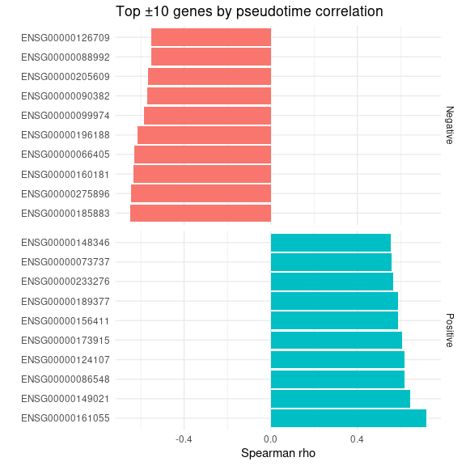

```r
top_genes_df <- gc_df %>%
  filter(!is.na(Cor)) %>%
  slice_max(Cor, n = 10) %>%
  mutate(Direction = "Positive") %>%
  bind_rows(
    gc_df %>% filter(!is.na(Cor)) %>% slice_min(Cor, n = 10) %>% mutate(Direction = "Negative")
  ) %>%
  mutate(Gene = factor(Gene, levels = unique(Gene)))

p_top_genes <- ggplot(top_genes_df, aes(x = Cor, y = Gene, fill = Direction)) +
  geom_col(show.legend = FALSE) +
  facet_grid(Direction ~ ., scales = "free_y") +
  labs(
    title = "Top ±10 genes by pseudotime correlation",
    x = "Spearman rho",
    y = ""
  ) +
  theme_minimal()

print(p_top_genes)
```

## Heatmap of top 10 positively correlated genes

Heatmap of top 10 genes by pseudotime correlation.

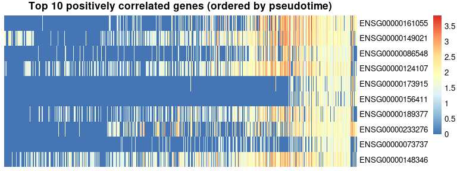

```r
top10 <- gc_df %>% filter(!is.na(Cor)) %>% slice_max(Cor, n = 10) %>% pull(Gene) %>% unique()

valid_cells <- colnames(seurat_obj)[!is.na(seurat_obj$pseudotime1)]
cells <- valid_cells[order(seurat_obj$pseudotime1[valid_cells])]

expr <- GetAssayData(seurat_obj, assay = "RNA", slot = "data")
present <- intersect(top10, rownames(expr))

mat <- expr[present, cells, drop = FALSE]
pheatmap(
  mat,
  cluster_rows = FALSE,
  cluster_cols = FALSE,
  show_colnames = FALSE,
  main = "Top 10 positively correlated genes (ordered by pseudotime)"
)
```

## Module-Score Trajectories (MI-derived modules)

Module scores are computed using genes from MI-derived communities in PT1. This ensures module trajectories are fully consistent with the inferred network structure.

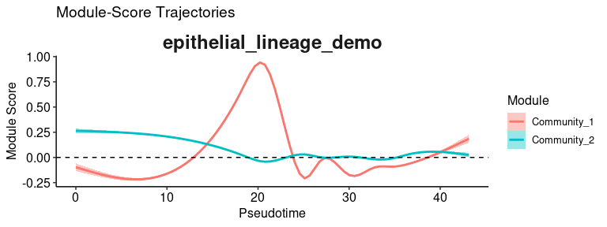

```r
# Identify PT1 index explicitly
pt1_idx <- which(sapply(comm_results, `[[`, "bin") == "PT1")
stopifnot(length(pt1_idx) == 1)

pt1_res <- comm_results[[pt1_idx]]

mods <- lapply(pt1_res$communities, head, 50)
names(mods) <- paste0("Community_", seq_along(mods))

p_modtraj <- plot_module_trajectories(
  comm_results,
  seurat_obj,
  bin_index = pt1_idx,
  custom_modules = mods,
  pseudotime_field = 'pseudotime1',
  cluster_field = "lineage_demo",
  cluster_id = "epithelial_lineage_demo",
  assay = "RNA"
)

print(p_modtraj)
```

```r
## GO enrichment for a representative MI community (PT1, Community 1)

## ===============================
## Hallmark enrichment of PT1 MI communities
## ===============================

suppressPackageStartupMessages({
  library(fgsea)
  library(msigdbr)
  library(org.Hs.eg.db)
})

hallmark <- msigdbr(species = "Homo sapiens") %>%
  filter(gs_cat == "H") %>%
  split(x = .$gene_symbol, f = .$gs_name)

ensembl_to_symbol_stats <- function(stats_ens) {
  ens_ids <- names(stats_ens)

  map <- AnnotationDbi::select(
    org.Hs.eg.db,
    keys     = ens_ids,
    keytype  = "ENSEMBL",
    columns  = "SYMBOL"
  )

  map <- map[!is.na(map$SYMBOL), c("ENSEMBL", "SYMBOL")]
  sym <- map$SYMBOL[match(ens_ids, map$ENSEMBL)]

  keep <- !is.na(sym)
  stats <- stats_ens[keep]
  names(stats) <- sym[keep]

  # collapse duplicate symbols deterministically
  stats <- tapply(stats, names(stats), max)
  stats <- sort(as.numeric(stats), decreasing = TRUE)
  names(stats) <- names(tapply(stats_ens[keep], sym[keep], max))

  stats
}

run_fgsea_safe <- function(stats, pathways, nperm = 5000) {
  overlap <- sum(names(stats) %in% unique(unlist(pathways)))
  message("Stats genes: ", length(stats), " | Overlap with pathway universe: ", overlap)

  if (overlap < 50) {
    message("Low overlap; enrichment may be uninformative for this demo.")
  }

  fg <- fgsea(
    pathways    = pathways,
    stats       = stats,
    nPermSimple = nperm
  )

  fg <- fg[order(fg$pval), ]
  fg
}

plot_fgsea_top <- function(fg, title, n = 15) {
  top <- fg %>% slice_head(n = n)
  ggplot(top, aes(x = NES, y = reorder(pathway, NES))) +
    geom_col() +
    labs(title = title, y = NULL) +
    theme_minimal()
}

g_pt1 <- pt1_res$consensus_graph
stopifnot("weight" %in% edge_attr_names(g_pt1))

cluster_gene_weights_ens <- lapply(pt1_res$communities, function(genes) {
  genes <- intersect(genes, V(g_pt1)$name)
  subg <- induced_subgraph(g_pt1, vids = genes)
  w <- strength(subg, weights = E(subg)$weight)
  w <- w - mean(w)            # optional; you can remove if it flattens too much
  sort(w, decreasing = TRUE)
})

stats_c1 <- ensembl_to_symbol_stats(cluster_gene_weights_ens[[1]])
fg_c1 <- run_fgsea_safe(stats_c1, hallmark, nperm = 10000)

print(nrow(fg_c1))
```

```
## [1] 45
```

```r
print(head(fg_c1, 10))
```

```
##                                pathway        pval       padj    log2err
##                                 <char>       <num>      <num>      <num>
##  1: HALLMARK_OXIDATIVE_PHOSPHORYLATION 0.001212948 0.05458266 0.45505987
##  2:     HALLMARK_FATTY_ACID_METABOLISM 0.003194888 0.06035113 0.32635161
##  3:                HALLMARK_GLYCOLYSIS 0.004023409 0.06035113 0.25264391
##  4:            HALLMARK_UV_RESPONSE_UP 0.016607355 0.18683274 0.13586293
##  5:                HALLMARK_PEROXISOME 0.025244300 0.22719870 0.12901539
##  6:              HALLMARK_ANGIOGENESIS 0.059196199 0.34723194 0.08224735
##  7:              HALLMARK_ADIPOGENESIS 0.061387900 0.34723194 0.06946518
##  8:     HALLMARK_XENOBIOTIC_METABOLISM 0.061730123 0.34723194 0.06720778
##  9:   HALLMARK_ESTROGEN_RESPONSE_EARLY 0.089069332 0.39059723 0.05208736
## 10:       HALLMARK_IL2_STAT5_SIGNALING 0.090137858 0.39059723 0.05343184
##             ES       NES  size  leadingEdge
##          <num>     <num> <int>       <list>
##  1:  0.9213589  1.688350     4 ACAA1, A....
##  2:  0.8469713  1.727919     6 ACAA1, A....
##  3:  0.6711375  1.800326    19 AGRN, AK....
##  4:  0.7504556  1.644580     8 ACAA1, A....
##  5:  0.9372289  1.435378     2 ACAA1, DHRS3
##  6: -0.9704433 -1.294992     1        VEGFA
##  7:  0.6839772  1.498897     8 ALDOA, A....
##  8:  0.6490185  1.511475    10 AKR1C2, ....
##  9:  0.5574674  1.459020    17 AQP3, AR....
## 10:  0.5874582  1.451641    13 AHNAK, B....
```

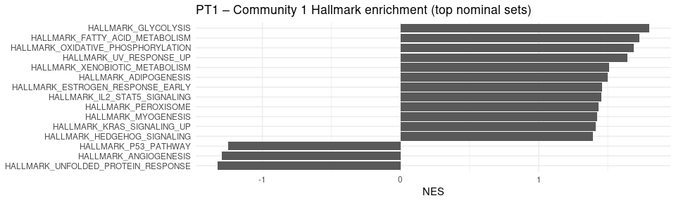

```r
print(plot_fgsea_top(fg_c1, "PT1 – Community 1 Hallmark enrichment (top nominal sets)"))
```

## Save Results

```r
# saveRDS(pt_results, "pseudotime_results.rds")
# saveRDS(comm_results, "pseudotime_communities.rds")
```